# Lending Classifier: Who Will Default (70 Points Total)

You work in the FinTech industry and your job is to routinely build classification models to help decide whether to issue a loan to borrowers based on their submitted applications. The data file `LoanStats.csv` contains some loans issued in the past, from which you would like to explore whether the text columns are predictive of the loans' repayment outcome.

```python
# Import necessary libraries
import pandas as pd
import numpy as np
import matplotlib.pyplot as plt
import seaborn as sns

from sklearn.model_selection import train_test_split
from sklearn.feature_extraction.text import TfidfVectorizer
from sklearn.linear_model import LogisticRegression
from sklearn.ensemble import RandomForestClassifier
from sklearn.metrics import classification_report, confusion_matrix, accuracy_score, roc_auc_score, roc_curve
import warnings
warnings.filterwarnings('ignore')
```

```python
# Load the data
df = pd.read_csv("LoanStats.csv", encoding="windows-1252", low_memory=False)
df.head()
```

|  | Loan ID | Amount Requested | Amount Funded By Investors | Interest Rate | Loan Length | Application Date | Application Expiration Date | Issued Date | CREDIT Grade | Loan Title | ... | Inquiries in the Last 6 Months | Accounts Now Delinquent | Delinquent Amount | Delinquencies (Last 2 yrs) | Months Since Last Delinquency | Public Records On File | Months Since Last Record | Education | Employment Length | Code |
| --- | --- | --- | --- | --- | --- | --- | --- | --- | --- | --- | --- | --- | --- | --- | --- | --- | --- | --- | --- | --- | --- |
| 0 | 87023 | 7500.0 | 7500.0 | 13.75% | 36 months | 6/7/2007 | 6/21/2007 | 6/27/2007 | E2 | Consolidation Loan | ... | 0.0 | 0.0 | 0.0 | 1.0 | 11.0 | 0.0 | 0.0 | NaN | < 1 year | NaN |
| 1 | 90376 | 5000.0 | 5000.0 | 7.43% | 36 months | 6/12/2007 | 6/26/2007 | 7/2/2007 | A2 | JAL Loan | ... | 0.0 | 0.0 | 0.0 | 0.0 | 0.0 | 0.0 | 0.0 | NaN | < 1 year | NaN |
| 2 | 90395 | 5000.0 | 5000.0 | 8.07% | 36 months | 6/12/2007 | 6/26/2007 | 7/2/2007 | A4 | MBA Loan Consolidation | ... | 0.0 | 0.0 | 0.0 | 0.0 | 0.0 | 0.0 | 0.0 | NaN | < 1 year | NaN |
| 3 | 90665 | 8500.0 | 8500.0 | 10.28% | 36 months | 6/13/2007 | 6/27/2007 | 7/3/2007 | C1 | Retiring credit card debt | ... | 1.0 | 0.0 | 0.0 | 1.0 | 5.0 | 0.0 | 0.0 | NaN | 3 years | NaN |
| 4 | 92187 | 2500.0 | 2500.0 | 8.07% | 36 months | 6/15/2007 | 6/29/2007 | 7/5/2007 | A4 | Home Improvement | ... | 0.0 | 0.0 | 0.0 | 0.0 | 0.0 | 0.0 | 0.0 | NaN | 4 years | NaN |

5 rows × 41 columns

## a) Cleaning the Target (15 points)

The target variable is `Status`. Code it into a binary variable:

- If the `Status` contains `Fully Paid`, code it as 0;
- If the `Status` contains `Charged Off` or `Late` or `Default` or `In Grace Period`, code it as 1;
- Drop all records with the other statuses.

Report the distribution of the prediction target (i.e., number of 1's and 0's).

```python
def code_status(status):
    if pd.isna(status):
        return None
    status = str(status)
    if 'Fully Paid' in status:
        return 0
    elif any(x in status for x in ['Charged Off', 'Late', 'Default', 'In Grace Period']):
        return 1
    else:
        return None

df['target'] = df['Status'].apply(code_status)


df_clean = df.dropna(subset=['target'])
df_clean['target'] = df_clean['target'].astype(int)

print(f"\nTarget Variable Distribution:")
print(df_clean['target'].value_counts().sort_index())
print(f"\nClass 0 (Fully Paid): {(df_clean['target'] == 0).sum()} ({(df_clean['target'] == 0).sum()/len(df_clean)*100:.2f}%)")
print(f"Class 1 (Default/Late): {(df_clean['target'] == 1).sum()} ({(df_clean['target'] == 1).sum()/len(df_clean)*100:.2f}%)")
```

```
Target Variable Distribution:
target
0    8255
1    3346
Name: count, dtype: int64

Class 0 (Fully Paid): 8255 (71.16%)
Class 1 (Default/Late): 3346 (28.84%)
```

## b) Preparing the Text (25 Points Total)

For each loan that stays in your sample, create a text column that concatenates the `Loan Title` and `Loan Description`. (5 points)

```python
df_clean['combined_text'] = (
    df_clean['Loan Title'].fillna('').astype(str) + ' ' +
    df_clean['Loan Description'].fillna('').astype(str)
).str.strip()

print("Example combined text:")
print(df_clean['combined_text'].iloc[0][:300])
```

```
Example combined text:
Consolidation Loan I plan to consolidate over $7,000 of debt: a combination of credit cards and student loans.
```

Randomly partition your data into training and test sets, where 75% of the samples go into the training set. (5 points)

```python
X = df_clean['combined_text']
y = df_clean['target']

X_train, X_test, y_train, y_test = train_test_split(
    X, y,
    test_size=0.25,
    random_state=42,
    stratify=y
)

print(f"Training set size: {len(X_train)} ({len(X_train)/len(X)*100:.1f}%)")
print(f"Test set size: {len(X_test)} ({len(X_test)/len(X)*100:.1f}%)")
```

```
Training set size: 8700 (75.0%)
Test set size: 2901 (25.0%)
```

Build a TF-IDF vectorizer based on the training set, and use it to convert the text of the training and test sets into feature matrices. (15 points)

```python
# Build TF-IDF vectorizer
vectorizer = TfidfVectorizer(
    max_features=5000,  # Limit features
    min_df=5,           # Ignore terms that appear in less than x documents
    max_df=0.8,         # Ignore terms that appear in more than x % of documents
    ngram_range=(1, 2), # Include unigrams and bigrams (1,2)
    strip_accents='unicode',
    lowercase=True,
    stop_words='english'
)

# Fit vectorizer on training data only

vectorizer.fit(X_train)

# Transform both training and test sets

X_train_tfidf = vectorizer.transform(X_train)

X_test_tfidf = vectorizer.transform(X_test)


print(f"Sparsity: {(1 - X_train_tfidf.nnz / (X_train_tfidf.shape[0] * X_train_tfidf.shape[1]))*100:.2f}%")
feature_names = vectorizer.get_feature_names_out()
print(f"\nSample features: {list(feature_names[:20])}")
print(f"High sparsity to be expected")
```

```
Sparsity: 99.35%

Sample features: ['00', '00 car', '00 credit', '00 loan', '00 mo', '00 month', '00 monthly', '00 pay', '00 total', '00 utilities', '000', '000 00', '000 000', '000 consolidate', '000 credit', '000 debt', '000 dollars', '000 loan', '000 miles', '000 month']
High sparsity to be expected
```

## c) Predictive Modeling (30 Points Total)

Fit a **logistic regression** model and a **random forest** model based on the **training set**. Compare these models' **performance** on the **test set**.

Note: If classes are imbalanced, the `class_weight` option in each model might be useful. Handling class imbalance problem is optional if your model is nontrivial (i.e., not classifying all samples into one class).

Also note: If you would like to optimize any hyperparameter (e.g., number of tress in the random forest), please be sure to only do that using the training set. You may consider a k-fold cross-validation in that case. Hyperparameter optimization is not required for this assignment.

```
Logistic Regression
Accuracy: 0.6170
ROC-AUC Score: 0.6439

Confusion Matrix:
[[1333  731]
 [ 380  457]]

Random Forest
Accuracy: 0.6005
ROC-AUC Score: 0.6198

Confusion Matrix:
[[1300  764]
 [ 395  442]]
              Model  Accuracy  ROC-AUC
Logistic Regression  0.617029 0.643876
      Random Forest  0.600483 0.619820
```

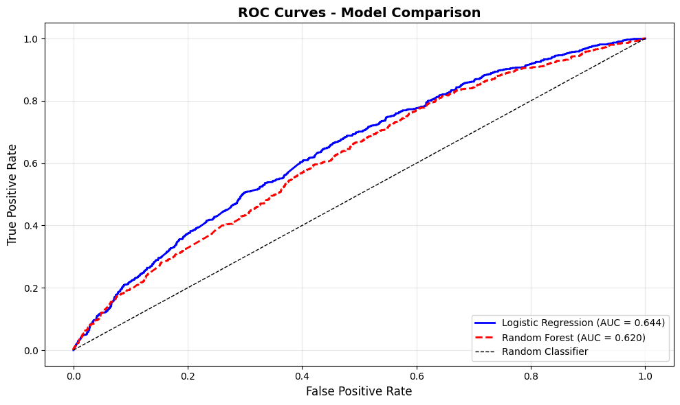

```
Somewhat suprsingly the Logistic Regression performs better on the holdout sample
boasting both a slighlty higher accuracy and ROC-AUC score
However random forests have been known to struggle with extreme sparsity
```

```python
# Train Logistic Regression Model


lr_model = LogisticRegression(
    class_weight='balanced',
    max_iter=1000,
    random_state=42,
    solver='liblinear'
)


lr_model.fit(X_train_tfidf, y_train)

print(f"Logistic Regression")
# Predictions
y_pred_lr = lr_model.predict(X_test_tfidf)
y_pred_proba_lr = lr_model.predict_proba(X_test_tfidf)[:, 1]

# Performance metrics

print(f"Accuracy: {accuracy_score(y_test, y_pred_lr):.4f}")
print(f"ROC-AUC Score: {roc_auc_score(y_test, y_pred_proba_lr):.4f}")
print("\nConfusion Matrix:")
cm_lr = confusion_matrix(y_test, y_pred_lr)
print(cm_lr)



#Random Forest Train


rf_model = RandomForestClassifier(
    n_estimators=100,
    class_weight='balanced',
    max_depth=20,
    min_samples_split=10,
    random_state=42,
    n_jobs=-1
)

rf_model.fit(X_train_tfidf, y_train)

print(f"\nRandom Forest")
# Predictions
y_pred_rf = rf_model.predict(X_test_tfidf)
y_pred_proba_rf = rf_model.predict_proba(X_test_tfidf)[:, 1]

# Performance metrics
print(f"Accuracy: {accuracy_score(y_test, y_pred_rf):.4f}")
print(f"ROC-AUC Score: {roc_auc_score(y_test, y_pred_proba_rf):.4f}")
print("\nConfusion Matrix:")
cm_rf = confusion_matrix(y_test, y_pred_rf)
print(cm_rf)

# Model Comparison

comparison_df = pd.DataFrame({
    'Model': ['Logistic Regression', 'Random Forest'],
    'Accuracy': [
        accuracy_score(y_test, y_pred_lr),
        accuracy_score(y_test, y_pred_rf)
    ],
    'ROC-AUC': [
        roc_auc_score(y_test, y_pred_proba_lr),
        roc_auc_score(y_test, y_pred_proba_rf)
    ]
})

print(comparison_df.to_string(index=False))

# Plot ROC Curves
fpr_lr, tpr_lr, _ = roc_curve(y_test, y_pred_proba_lr)
fpr_rf, tpr_rf, _ = roc_curve(y_test, y_pred_proba_rf)

plt.figure(figsize=(10, 6))
plt.plot(fpr_lr, tpr_lr, 'b-', linewidth=2,
         label=f'Logistic Regression (AUC = {roc_auc_score(y_test, y_pred_proba_lr):.3f})')
plt.plot(fpr_rf, tpr_rf, 'r--', linewidth=2,
         label=f'Random Forest (AUC = {roc_auc_score(y_test, y_pred_proba_rf):.3f})')
plt.plot([0, 1], [0, 1], 'k--', linewidth=1, label='Random Classifier')
plt.xlabel('False Positive Rate', fontsize=12)
plt.ylabel('True Positive Rate', fontsize=12)
plt.title('ROC Curves - Model Comparison', fontsize=14, fontweight='bold')
plt.legend(loc='lower right', fontsize=10)
plt.grid(True, alpha=0.3)
plt.tight_layout()
plt.show()

print(f"Somewhat suprsingly the Logistic Regression performs better on the holdout sample")
print(f"boasting both a slighlty higher accuracy and ROC-AUC score")
print(f"However random forests have been known to struggle with extreme sparsity")
```